# brms model report: esp_4_barcelona

### Rainfall in the last day (scaled)

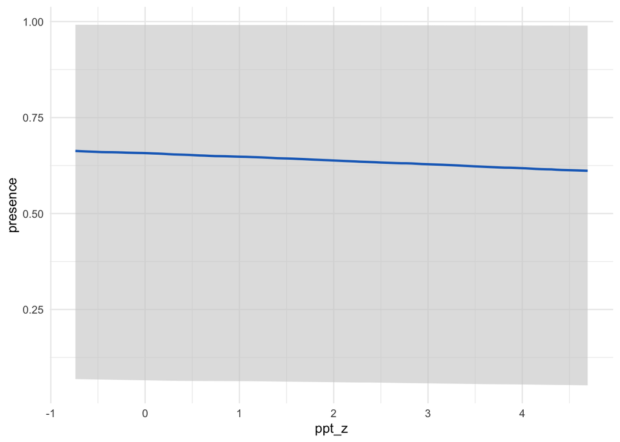

### Green-space proximity (NDVI)

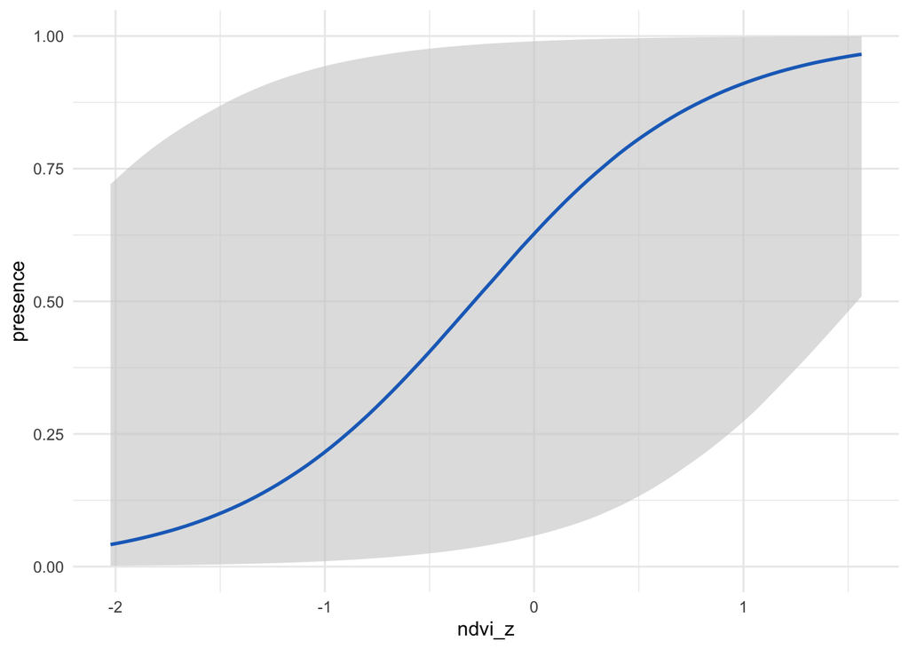

### Elevation (scaled)

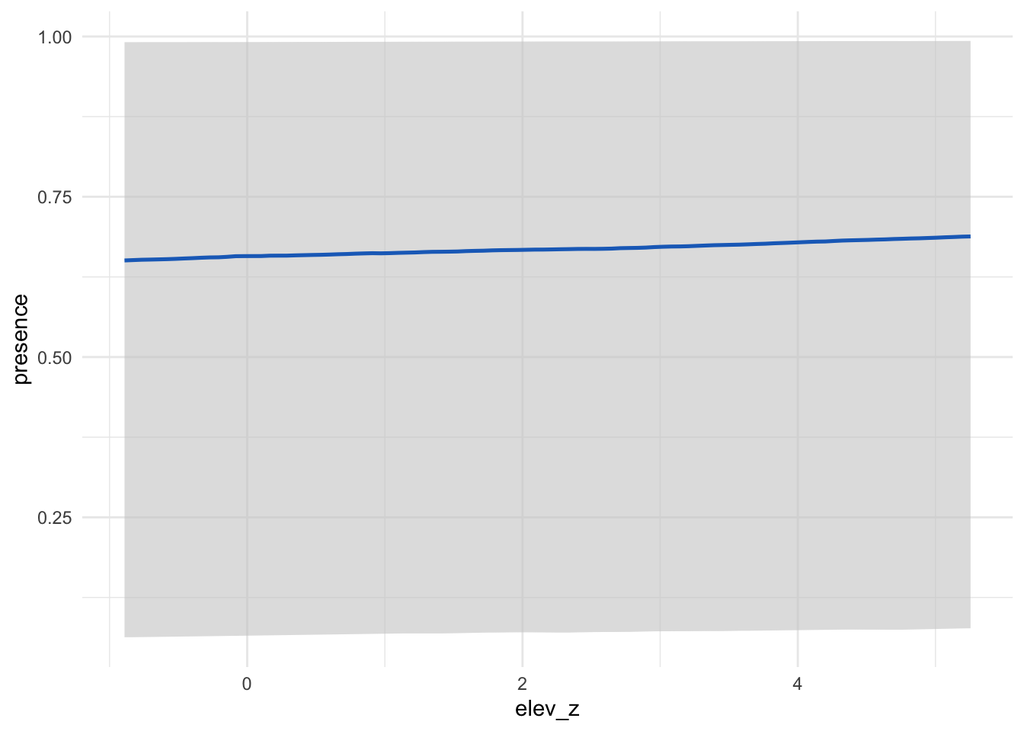

### Day of the year

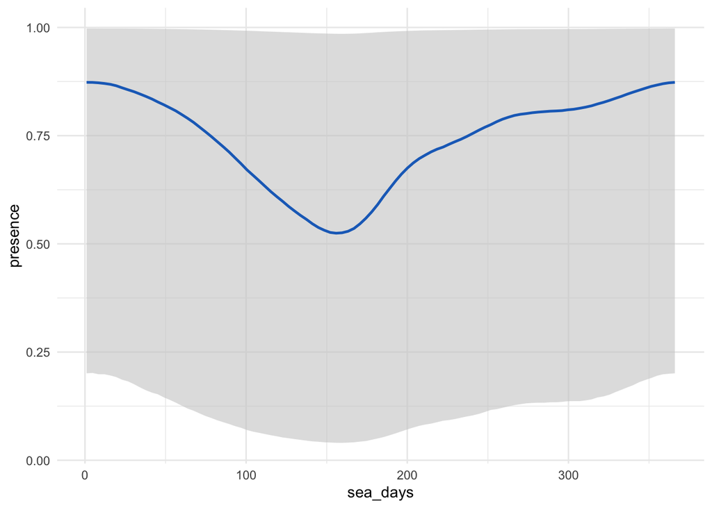

### Maximum temperature (scaled)

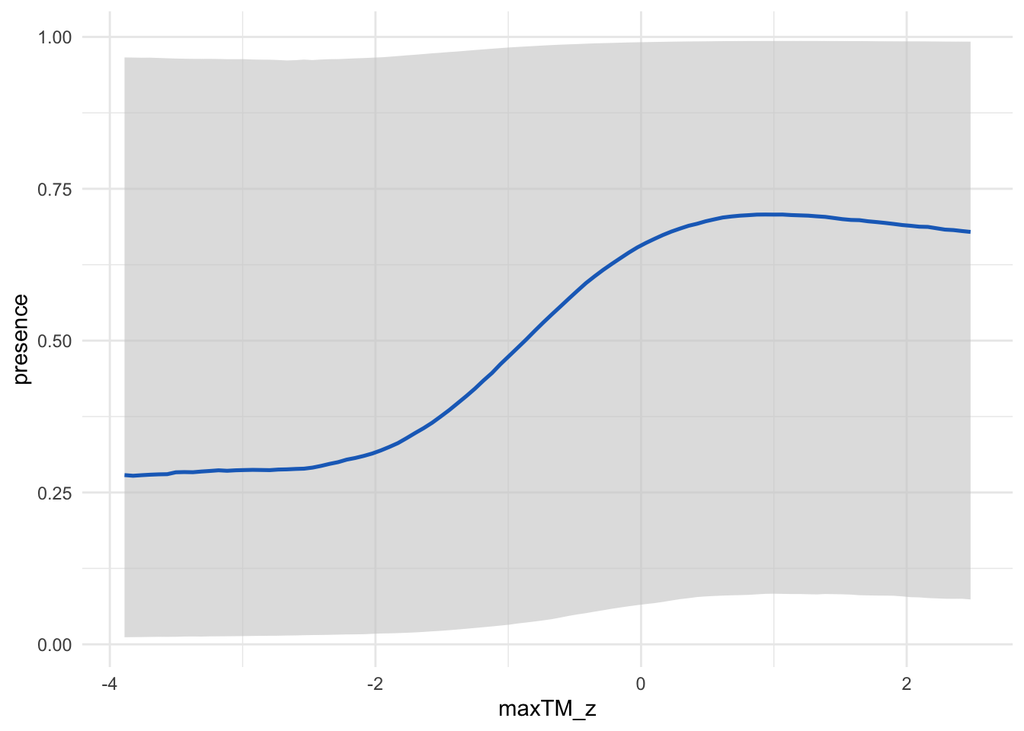

## Land-cover random effects

| landcover | term | estimate | est_error | lower | upper |
| --- | --- | --- | --- | --- | --- |
| 0 | Intercept | 6.69 | 4.35 | 0.64 | 17.72 |
| 30 | Intercept | 5.46 | 4.45 | -0.69 | 16.36 |
| 60 | Intercept | 5.15 | 4.58 | -1.23 | 16.23 |
| 80 | Intercept | 4.13 | 4.71 | -2.63 | 15.72 |
| 50 | Intercept | -2.69 | 1.87 | -6.75 | 0.74 |
| 10 | Intercept | -6.23 | 1.87 | -10.29 | -2.77 |
| 20 | Intercept | -6.90 | 1.90 | -11.01 | -3.43 |